# Impact of big match results on stock market value of principal sponsor.

**By:** Aayush Srivastava, Veldi Sushruth, E Akarsh Reddy

# Disclaimer:

This study is meant for the sole purpose of analysis. This is **NOT** financial advice and cannot be interpreted as such under any circumstance. Neither the author(s) nor the contributor(s) will be responsible under any circumstance for any losses incurred by any individual, business, organization, partnership, company, society or any other third party. The values has been taken from reputable sources on the internet believed to be true, we wont be responsible for any data inconsistencies or misinformation.

# Brief:

We all know and love the beautiful game including us. Fortunately we also have a passion for the stock markets. And sitting in home during the Covid-19 pandemic we decided to find if there exists any relation between the two. Hence we decided to perform a simple study: **Do the results of big football matches have an impact on the stock market value of principal sponsor?**

# Abstract:

Although we performed this study with high hopes of finding a positive relation between the result of the matches and variations in stock prices of principal sponsor, unfortunately we conclude that no such relationship exists neither positive nor negative, the variations seem to be influenced by other major factors beyond the scope of this study. Although we didn't find a relation between the match result and stock market value of the sponsor, we did find a possible relation between them before the match day.**(This is just a hypothesis further research required to reach a conclusion.)**

# Analysis:

## Loading and processing data:

```python
import numpy as np
import pandas as pd
import matplotlib.pyplot as plt
```

```python
rise=[0,0]
#This variable keeps a track if a temporary bubble is created after the match index 0 corresponds to false and index 1 corresponds to true
```

```python
data=pd.read_excel('D:\Data Analysis\Football-Market 1\Football data.xlsx',sep='\s*,\s*')
data=data.dropna()
data['Id']=data.reset_index().index
data.head()
```

|  | Date | Game Name | Club | Country | Brand | Share Name | Value prior (2 days) | On game day (current) | Value for ST (2 days) | Value for LT (7-9days) | Currency | Id |
| --- | --- | --- | --- | --- | --- | --- | --- | --- | --- | --- | --- | --- |
| 1 | 2019-09-19 | UCL | PSG | France | Accor Live Limitless | Accor SA | 38.97 | 39.70 | 38.90 | 38.37 | EUR | 0 |
| 2 | 2019-10-02 | UCL | Bayern Munich | Germany | Deutsche Telekom | Deutsche Telekom AG (DTE.DE) | 15.39 | 15.05 | 15.13 | 15.46 | EUR | 1 |
| 4 | 2019-11-27 | UCL | Juventus | Italy | Jeep | Fiat Chrysler Automobiles N.V. (FCA.MI) | 13.59 | 13.61 | 13.42 | 13.15 | EUR | 2 |
| 5 | 2019-11-28 | UCL | Barcelona | Spain | Rakuten | Rakuten Inc | 8.59 | 8.60 | 8.49 | 8.46 | USD | 3 |
| 6 | 2020-02-19 | UCL | Dortmund(BVB) | Germany | Evonik | Evonik Industries AG (EVK.DE) | 26.97 | 26.85 | 26.85 | 23.35 | EUR | 4 |

```python
x=['2 days prior','Match day','2 days after','Long Term Value']
def draw(i):
    plt.plot(x,data.iloc[i][6:10])
    plt.title('Plot')
    plt.ylabel('Values')
    plt.xlabel('Time')
    info(i)
```

```python
def info(i):
    d=data.iloc[i]
    print('       Date: '+str(d['Date']).split()[0])
    print('       Club: '+d['Club'])
    print(' Share Name: '+d['Share Name'])
    print('   Currency: '+d['Currency'])
```

```
       Date: 2019-09-19
       Club: PSG
 Share Name: Accor SA
   Currency: EUR
```

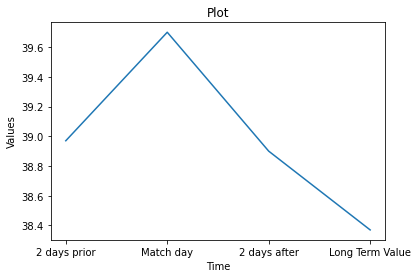

```python
draw(0)
```

**Analysis:** No rise observed.

```python
rise[0]+=1
```

```
       Date: 2019-10-02
       Club: Bayern Munich
 Share Name: Deutsche Telekom AG (DTE.DE)
   Currency: EUR
```

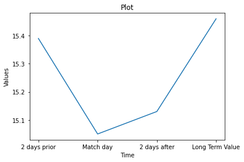

```python
draw(1)
```

**Analysis:** Rise observed.

```python
rise[1]+=1
```

```
       Date: 2019-11-27
       Club: Juventus
 Share Name: Fiat Chrysler Automobiles N.V. (FCA.MI)
   Currency: EUR
```

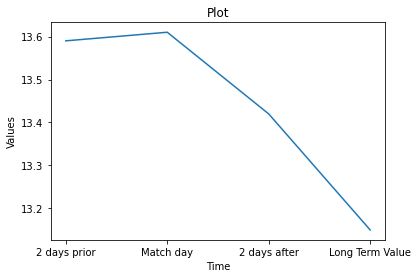

```python
draw(2)
```

**Analysis:** No rise observed.

```python
rise[0]+=1
```

```
       Date: 2019-11-28
       Club: Barcelona
 Share Name: Rakuten Inc
   Currency: USD
```

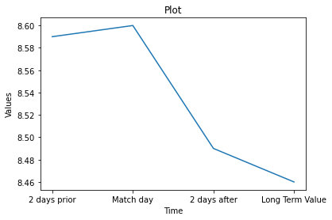

```python
draw(3)
```

**Analysis:** No rise observed.

```python
rise[0]+=1
```

```
       Date: 2020-02-19
       Club: Dortmund(BVB)
 Share Name: Evonik Industries AG (EVK.DE)
   Currency: EUR
```

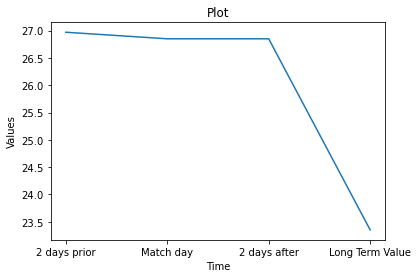

```python
draw(4)
```

**Analysis:** No rise observed.

```python
rise[0]+=1
```

```
       Date: 2020-03-12
       Club: Atletico Madrid
 Share Name: Plus500 Ltd
   Currency: GBp
```

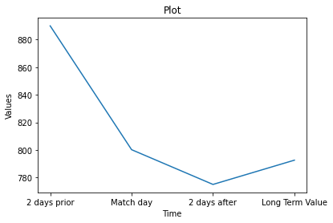

```python
draw(5)
```

**Analysis:** No rise observed.

```python
rise[0]+=1
```

```
       Date: 2020-08-15
       Club: Bayern Munich
 Share Name: Deutsche Telekom AG (DTE.DE)
   Currency: EUR
```

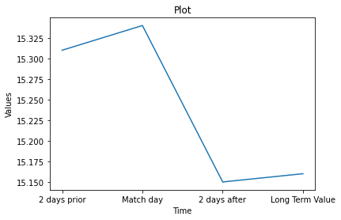

```python
draw(6)
```

**Analysis:** No rise observed.

```python
rise[0]+=1
```

```
       Date: 2018-10-23
       Club: Juventus
 Share Name: Fiat Chrysler Automobiles N.V. (FCA.MI)
   Currency: EUR
```

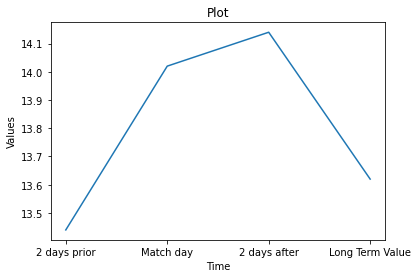

```python
draw(7)
```

**Analysis:** Rise observed.

```python
rise[1]+=1
```

```
       Date: 2018-11-06
       Club: Crvena zvezda
 Share Name: OGZPY
   Currency: USD
```

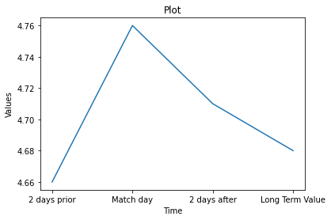

```python
draw(8)
```

**Analysis:** No rise observed.

```python
rise[0]+=1
```

```
       Date: 2018-11-07
       Club: Manchester Utd
 Share Name: General Motors Company (GM)
   Currency: USD
```

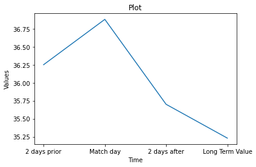

```python
draw(9)
```

**Analysis:** No rise observed.

```python
rise[0]+=1
```

```
       Date: 2018-11-28
       Club: Tottenham
 Share Name: AIA GROUP LTD (7A2.BE)
   Currency: EUR
```

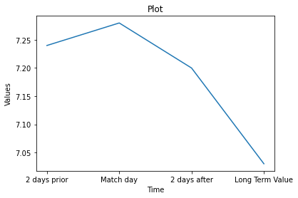

```python
draw(10)
```

**Analysis:** No rise observed.

```python
rise[0]+=1
```

```
       Date: 2018-12-12
       Club: CSKA Moskva
 Share Name: Rosetti Marino SpA (YRM.MI)
   Currency: EUR
```

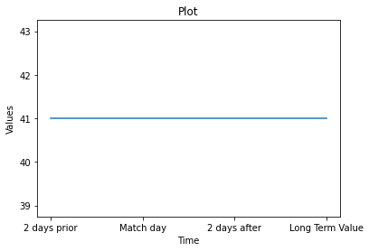

```python
draw(11)
```

**Analysis:** No rise observed.

```python
rise[0]+=1
```

```
       Date: 2018-12-12
       Club: Young Boys
 Share Name: OBI Pharma
   Currency: TWD
```

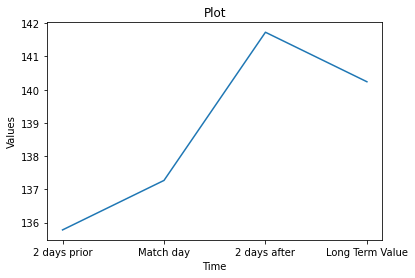

```python
draw(12)
```

**Analysis:** Rise observed.

```python
rise[1]+=1
```

```
       Date: 2019-05-01
       Club: Barcelona
 Share Name: Rakuten Inc
   Currency: USD
```

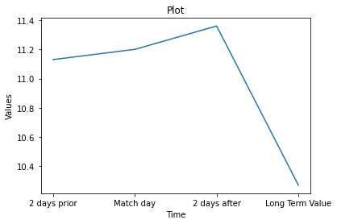

```python
draw(13)
```

**Analysis:** Rise observed.

```python
rise[1]+=1
```

```
       Date: 2019-05-07
       Club: Liverpool
 Share Name: Standard Chartered PLC (STAN.L)
   Currency: GBp
```

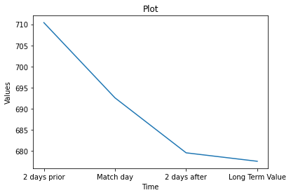

```python
draw(14)
```

**Analysis:** No rise observed.

```python
rise[0]+=1
```

```
       Date: 2019-05-08
       Club: Tottenham
 Share Name: AIA Group Ltd(1299.HK)
   Currency: HKD
```

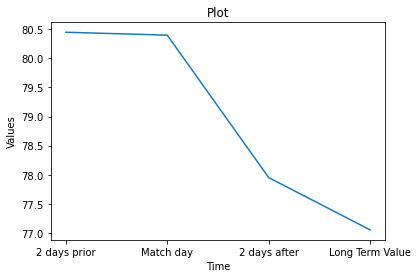

```python
draw(15)
```

**Analysis:** No rise observed.

```python
rise[0]+=1
```

```
       Date: 2019-05-29
       Club: Chelsea
 Share Name: YOKOHAMA RUBBER (YRB.BE)
   Currency: EUR
```

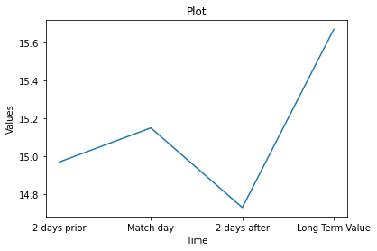

```python
draw(16)
```

```python
rise[1]+=1
```

```
       Date: 2018-04-10
       Club: Liverpool
 Share Name: Standard Chartered PLC (STAN.L)
   Currency: GBp
```

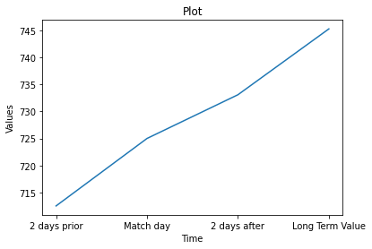

```python
draw(17)
```

**Analysis:** Rise observed.

```python
rise[1]+=1
```

```
       Date: 2020-06-26
       Club: Chelsea
 Share Name: YOKOHAMA RUBBER (YRB.BE)
   Currency: EUR
```

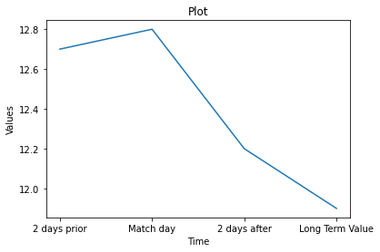

```python
draw(18)
```

**Analysis:** No rise observed.

```python
rise[0]+=1
```

```
       Date: 2020-03-08
       Club: Manchester Utd
 Share Name: General Motors Company (GM)
   Currency: USD
```

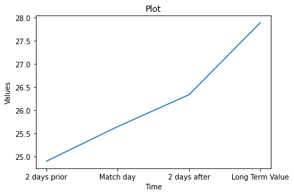

```python
draw(19)
```

**Analysis:** Rise observed.

```python
rise[1]+=1
```

```
       Date: 2020-02-02
       Club: Tottenham
 Share Name: AIA GROUP LTD (7A2.BE)
   Currency: EUR
```

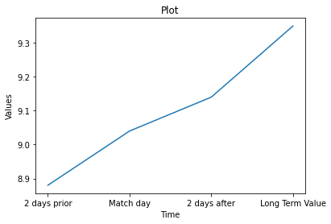

```python
draw(20)
```

**Analysis:** Rise observed.

```python
rise[1]+=1
```

```
       Date: 2019-10-24
       Club: Inter Milan
 Share Name: Pirelli & C. S.p.A. (PIRC.MI)
   Currency: EUR
```

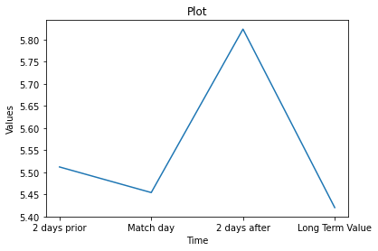

```python
draw(21)
```

**Analysis:** Rise observed.

```python
rise[1]+=1
```

```
       Date: 2019-11-10
       Club: Liverpool
 Share Name: Standard Chartered PLC (STAN.L)
   Currency: GBp
```

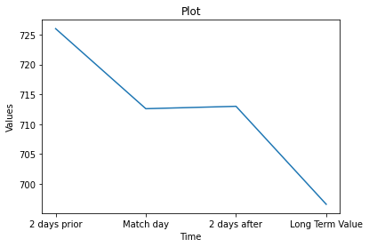

```python
draw(22)
```

**Analysis:** No rise observed.

```python
rise[0]+=1
```

```
       Date: 2019-08-11
       Club: Manchester Utd
 Share Name: General Motors Company (GM)
   Currency: USD
```

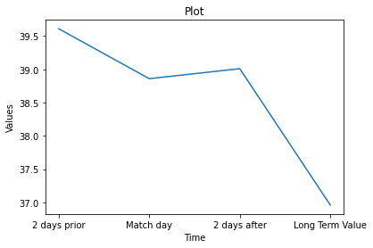

```python
draw(23)
```

**Analysis:** Rise observed.

```python
rise[1]+=1
```

```
       Date: 2019-09-22
       Club: Inter Milan
 Share Name: Pirelli & C. S.p.A. (PIRC.MI)
   Currency: EUR
```

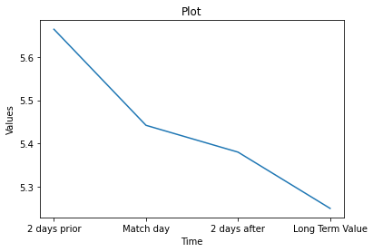

```python
draw(24)
```

**Analysis:** No rise observed.

```python
rise[0]+=1
```

```
       Date: 2020-06-20
       Club: Dortmund(BVB)
 Share Name: Evonik Industries AG (EVK.DE)
   Currency: EUR
```

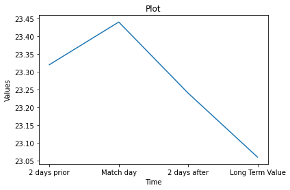

```python
draw(25)
```

**Analysis:** No rise observed.

```python
rise[0]+=1
```

```
       Date: 2019-11-28
       Club: Schalke 04
 Share Name: OGZPY
   Currency: USD
```

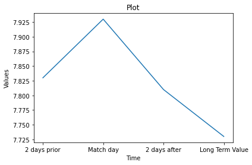

```python
draw(26)
```

**Analysis:** No rise observed.

```python
rise[0]+=1
```

```
       Date: 2018-10-28
       Club: Barcelona
 Share Name: Rakuten Inc
   Currency: USD
```

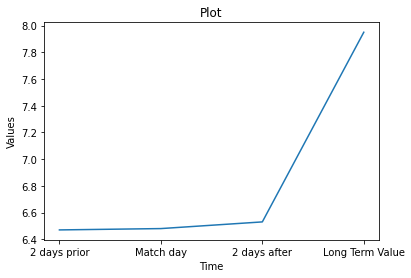

```python
draw(27)
```

**Analysis:** Rise observed.

```python
rise[1]+=1
```

```
       Date: 2019-11-11
       Club: Marseille
 Share Name: Orange S.A. (ORA.PA)
   Currency: EUR
```

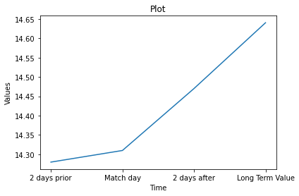

```python
draw(28)
```

**Analysis:** Rise observed.

```python
rise[1]+=1
```

```
       Date: 2019-02-21
       Club: Atletico Madrid
 Share Name: Plus500 Ltd
   Currency: GBp
```

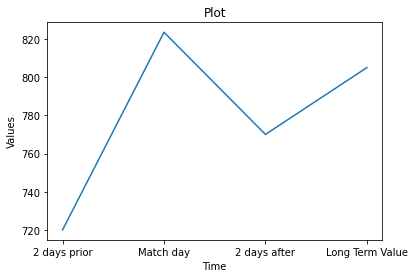

```python
draw(29)
```

**Analysis:** No rise observed.

```python
rise[0]+=1
```

```
       Date: 2019-11-11
       Club: Juventus
 Share Name: Fiat Chrysler Automobiles N.V. (FCA.MI)
   Currency: EUR
```

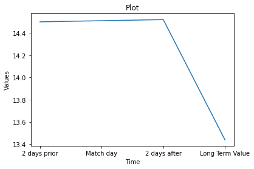

```python
draw(30)
```

**Analysis:** No rise observed.

```python
rise[0]+=1
```

```
       Date: 2018-05-17
       Club: Atletico Madrid
 Share Name: Plus500 Ltd
   Currency: GBp
```

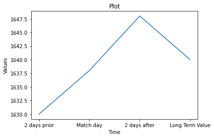

```python
draw(31)
```

**Analysis:** Rise observed.

```python
rise[1]+=1
```

## Final Stats:

```python
print('Rise occours:'+str(rise[1])+'/32')
print('Rise dose not occurs:'+str(rise[0])+'/32')
```

```
Rise occours:13/32
Rise dose not occurs:19/32
```

# Result: